# Observations Of A Library User On The Libraries And Archives Review Phase 1 Cabinet Report

A Library User

6 June 2025

## Introduction

I am a regular library user who borrows books and uses the library as a space to study. My interest in reading the Libraries And Archives Review Phase 1 Cabinet Report is twofold. Firstly, I responded to the Phase 1 Consultation and secondly I have seen invitations to complete the Phase 2 Consultation.

### Library Service Usage

**Given that on page 1 RECOMMENDATIONS point 2 the Cabinet is being recommended and encouraged to support and agree “the findings of the needs assessment set out in appendix 1” I have focused on appendix 1.**

Appendix 1, page 7

Paragraph 2 states: “The trend of usage over previous years has been looked at in Table 1 and Table 2 with a summary presented in charts across Figure 4. The period of the data is included to cover pre-Covid years and then post-Covid years, noting that due to the closures and levels of service reduction during the period of the Covid pandemic this data has not been included.”

Yes there were closures and a level of service reduction during the period of the Covid pandemic. However, from a point of view of presentation of data, **total omission of data is not appropriate.** Unusual data points are in fact often revealing. During the periods of lock-down restrictions there was a particular emphasis made by those persons staffing the library during these periods on library users having their library card on entry to the library and for any issues made. There are **alternative approaches** such as partial inclusion of available data or clear disclaimers about gaps.

In England the first lock-down started on 2020/3/23. Non-essential retail reopened on 2020/6/15. The period between these two dates being 84 days. Most other business were allowed to re-open on 2020/7/4. The longer period being of 103 days duration. A partial lock-down began on 2020/11/5, lasting until 2020/12/2, a period of 27 days. So worst case a period of 103 + 27 = 130 days lost service in year 2020. Restrictions were put in place from 2021/1/5 until 2021/3/8, a period of 62 days. That leaves a lot of days, (365 * 2) - (130 + 62) = **538 days from 730 days (or 74% of the period) in both 2020 and 2021 in which service was available and therefore also data should be available. This data should be provided.**

**A single year difference or just a few observations isn’t enough to declare a trend.** Ideally, you want at least 5-10 years of data (or more) depending on the variability of your data set. Short-term fluctuations should not be mistaken for long-term patterns. **Omitting two years of available data whilst still claiming a trend introduces serious issues of bias and misrepresentation.** This raises questions about whether the omission was intentional, or just an oversight, but either way it undermines the reliability of the conclusion. **What justifies the omission?**

Statement: “Across 2023-24, users made 170,565 physical and online visits to libraries and were issued with 169,051 reading materials.” How was 170,565 calculated? Table 1 states Total number of physical visits 2023-24 as 146,019 and Total e-resource lending 19,767. 146,019 + 19767 = 165,786. There is understandingly no category called “online visits” and no other combinations of the figures from table 1 that sum to 170,565. **The figure of 170,565 appears to be an error.**

**Any data analysis should include a key to explain the terms used.** To give a specific example **what does a physical visit actually mean and how is it measured?** I understand from discussion with a member of library staff that the measurement is taken by some instrument that registers a person (or object, for example a pram) passing through the building entry point. This should be explained. Further, it should be made clear to readers of this report that **there exist physical differences in the building layout at each branch, space provision and services provided in those spaces which have a direct impact on the count of physical visits**. To be specific, at Cleethorpes a person entering the building to visit the tourist information/theater ticket desk only would count as a physical visit. Also Cleethorpes has toilet provision directly accessible from the adult book lending library space whereas Grimsby and Waltham do not. At Grimsby is the measurement taken as a person (or object, such as a pram) passes through the sliding door at the top of the steps/wheelchair access ramp into the reception area or is it taken on the entry from the reception area into the book lending area on the ground floor. If the former then there is some service provision in the reception area space not directly linked the library book loans. Immingham branch is part of the town council civic center and has a meeting room that seats up to 100. As another example, **what exactly does an in person issue mean?** When a library user visits the library in person to renew a loan on a single book does that count as 1 issue? What about to renew the loan and two books, does this count as two issues? What about renewals made by telephone or online via a library users account? **Is there a measure of non in person issues, i.e. re-issues via telephone or made via users online library account? The ease with which a user can renew a loan is an important element of the library users experience. If not then should there not be one? If yes why is it not included in this presentation?** Another reason to have a key is to for example explain exactly what is meant by the **periods 2018-19, 2019-20, 2022-23, and 2023-24? As it stands this is ambiguous.** 2023-24 could mean 2023-April-01 to 2024-Mar-31, or 2023-Jun-01 to 2024-May-31, or some other variation. I suspect it relates to a financial reporting period. Is this really appropriate for this data? Would it not be more appropriate to have used the figures for the calendar year? In short **the terms used in the presentation of data should be explained.**

**All measurement is subject to error.** Even relatively simple discrete type data such as count measurement of physical visits, in person issues, etc., is subject to error. Some measurements are subject to more error than others. The degree depending on the device used to take the measurement. In addition, the technologies associated with measurement devices have different levels of maintenance need and also reliability. **What devices and technologies are used to measure e.g., physical visits and in person issues? Does each branch use devices using the same technology to take the measurements?** I know one branch uses a different technology to measure one of these counts than other branches. **Were there periods, within the periods covered by the data in Tables 1 and 2, when the measurement devices were not measuring due to breakdown or due to being taken down for maintenance?**

**The manner of presentation of Table 1 Total library service usage with a single shaded column between the two preceding columns titled 2018-19 and 2019-20 and succeeded by two columns titled 2022-23 and 2023-24 could be misleading.** At first glance the reader would see one shaded column and equate this to one year when in fact there are two full years of missing data. This table is presented in the same way in 1.20. The same applies to Table 2 - Library service usage by branch.

There are **seven discrepancies between the figures presented in Table 1 and their equivalents computed from Table 2.** These are as follows:

1. Total number of in person issues 2018-19 213,924 Table 2 Total number of in person issues 2018-19 Cleethorpes 69,824, Grimsby 75,701, Immingham 26,262, Waltham 39,432. 69,824 + 75,701 + 26,262 + 39,432 = 211,219 and not 213,924.
2. Total core event & programme attendance 2018-19 15,608 Table 2 Total core event & programme attendance 2018-19 Cleethorpes 4,338, Grimsby 2,501, Immingham 1,297, Waltham 5,900 4,338 + 2,501 + 1,297 + 3,900 = 14,036 and not 15,608
3. Total number of computer hours used 2019-20 16,624 Table 2 Total number of computer hours used 2019-20 Cleethorpes 5,139, Grimsby 9,934, Immingham 735, Waltham 817 5,139 + 9,934 + 735 + 817 = 16,625 and not 16,624
4. Total core event & programme attendance 2019-20 19,454 Table 2 Total core event & programme attendance 2019-20 Cleethorpes 5,373, Grimsby 4,093, Immingham 1,459, Waltham 4,997 5,373 + 4,093 + 1,459 + 4,997 = 15,922 and not 19,454
5. Total core event & programme attendance 2022-23 16,619 Table 2 Total core event & programme attendance 2022-23 Cleethorpes 2,534, Grimsby 1,615, Immingham 1,735, Waltham 2,046 2,534 + 1,615 + 1,735 + 2,046 = 7,930 and not 16,619
6. Total number of physical visits 2023-24 146,019 Table 2 Total number of physical visits 2023-24 Cleethorpes 38,287, Grimsby 50,134, Immingham 23,662, Waltham 36,896 38,287 + 50134 + 23,662 + 36,896 = 148,979 and not 146,019
7. Total core event & programme attendance 2023-24 18,521 Table 2 Total core event & programme attendance 2023-24 Cleethorpes 2,910, Grimsby 1,759, Immingham 1,576, Waltham 2,095 2,910 + 1,759 + 1,576 + 2,095 = 8,340 and not 18,521

Reported vs Computed Totals

| Metric | Reported_Value | Computed_Value | Discrepancy |
| --- | --- | --- | --- |
| In-person issues 2018-19 | 213924 | 211219 | 2705 |
| Event attendance 2018-19 | 15608 | 14036 | 1572 |
| Computer hours 2019-20 | 16624 | 16625 | -1 |
| Event attendance 2019-20 | 19454 | 15922 | 3532 |
| Event attendance 2022-23 | 16619 | 7930 | 8689 |
| Physical visits 2023-24 | 146019 | 148979 | -2960 |
| Event attendance 2023-24 | 18521 | 8340 | 10181 |

**The raw data from which Table 1 and Table 2 were created are made publicly available so that these tables can be reproduced.**

Bottom of page 10 states “Some of the headline movements include: . 43% decline in total physical library visits from 2018-19 to 2023-24 . 67% decline in total number of computer hours used from 2018-19 to 2023-24 . 391% increase in total e-resource lending from 2018-19 to 2023-24”

Table 1 on page 7 reports Total e resource lending 2018-19 as 5,055 and Total e resource lending 2023-24 as 19,767. That equates to a **291%** increase [(5055 - 19767) / 19767 = -2.910] and **not 391%**. **The same error overstating an increase is printed in section 1.21.**

Note that 19,767 is still only less than 12% of the Total number of in person issues in the same period.

The headline figure of a 43% decline in total physical library visits from 2018-19 to 2023-24 hides the fact that for Waltham there was a 1% increase in physical library visits in the same period. Neither does it show that The total number of in person issues decreased by 20% over the same period. The report offers no comment on the differing levels of decline between physical visits and in person issues. Could it be that library users are visiting the library less often and checking out more books on each visit? I am confident that **more library users are aware on the limit on the number of books that can be checked out on each issue post-Covid than was the case pre-Covid.** If it is the case that some users are checking out more books on each visit then this would be an example of library user behavioral changes impacting the count of physical visits and not reflecting a reduction in library user engagement. **The headline figures referred to section 1.21 hide important information and one of these has a significant error.**

Decreases in the number of issues by branch over the same period were: Cleethorpes 26%, Grimsby 27%, Immingham 3%, and Waltham 7%. There is no mention in the report of the large difference between the levels of decrease seen in Cleethorpes and Grimsby with those seen in Immingham and Waltham. **If data over a longer period was available I expect changes in the number of issues in the order of [3%, 7%] would be seen to be normal.**

Why choose to compare just 2018-19 with just 2023-24? **What is the justification for choosing a single year from the before and after the missing data period rather than, say the average of the two years before and after?** Why not compare the average of 2018-19 and 2019-20 with the average of 2022-23 and 2023-24 thereby making more use of the scant amount of data that has been selected to begin with? Having chosen to select a limited amount of data pre and post Covid to then throw half of that away in the comparison is a strange decision. As it happens, in this case it makes little difference. Nevertheless, the decision taken is unexplained and rarely appropriate.

Considering the metric of issues per visit, given that I have little information to go on as to what exactly constitutes a *physical visit* I get the following:

| issues per visit | branch | period |
| --- | --- | --- |
| 0.96 | Cleethorpes | 2018-19 |
| 0.98 | Cleethorpes | 2019-20 |
| NA | Cleethorpes | 2020-21 |
| NA | Cleethorpes | 2021-22 |
| 1.35 | Cleethorpes | 2022-23 |
| 1.35 | Cleethorpes | 2023-24 |
| 0.78 | Grimsby | 2018-19 |
| 0.81 | Grimsby | 2019-20 |
| NA | Grimsby | 2020-21 |
| NA | Grimsby | 2021-22 |
| 1.15 | Grimsby | 2022-23 |
| 1.10 | Grimsby | 2023-24 |
| **0.55** | Immingham | 2018-19 |
| **0.60** | Immingham | 2019-20 |
| NA | Immingham | 2020-21 |
| NA | Immingham | 2021-22 |
| 1.04 | Immingham | 2022-23 |
| 1.08 | Immingham | 2023-24 |
| 1.08 | Waltham | 2018-19 |
| 1.19 | Waltham | 2019-20 |
| NA | Waltham | 2020-21 |
| NA | Waltham | 2021-22 |
| 0.97 | Waltham | 2022-23 |
| 0.99 | Waltham | 2023-24 |

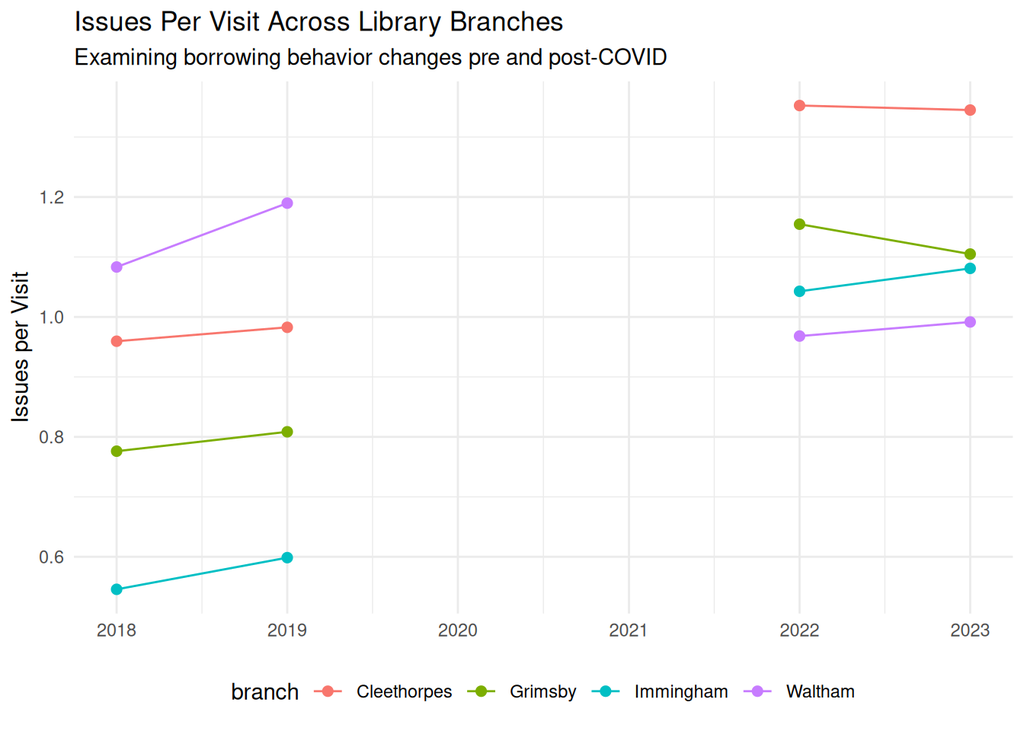

Of interest from the table and graph above is the particularly low values of issues per visit for Immingham for the periods 2018-19 and 2019-20. What is the reason for this difference in comparison to all other branches? The other point of interest is that Cleethorpes, Grimsby and Immingham all showed an increase in this ratio and only Waltham showed a decrease. What are the reason(s) for this? **Have some group(s) stopped using a meeting room in Immingham post Covid because they now choose to meet via video conference?** The same may apply for the other branches.

## Alternative Plots

As an alternative to the plots in Appendix 1, page 8, figure 4 titled **Library service usage trend charts**, specifically the plots with headers *Total number of physical visits* and **Total number of physical issues** I present the following:

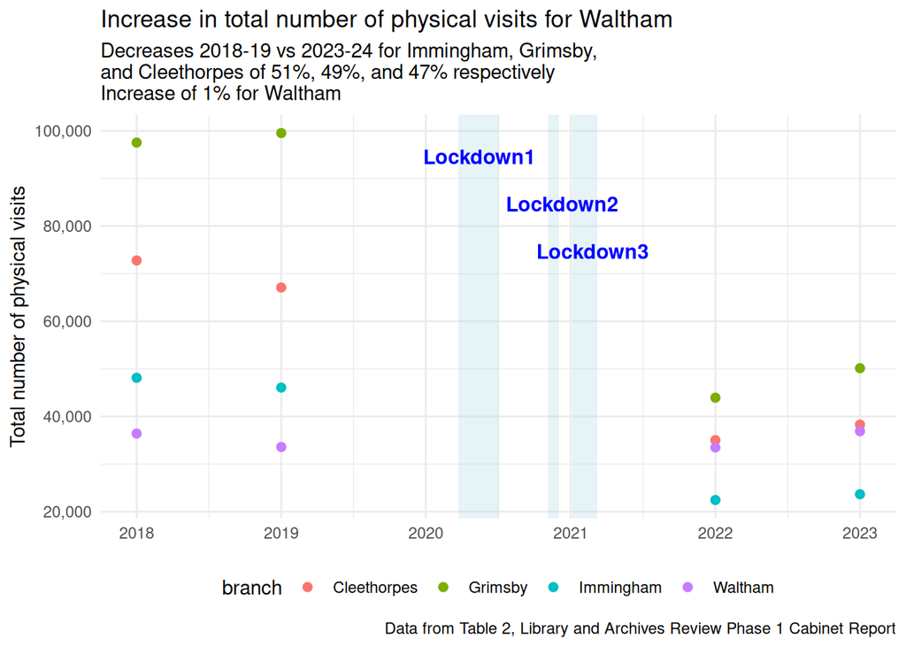

It can be clearly seen that **there was no large decrease in the total number of physical visits pre vs post-Covid for Waltham branch. There are two full years of missing data. Lock-down duration is a small proportion of two year period.** Why the difference? Work should be undertaken to explore this in detail. As a user of Waltham, Grimsby, Cleethorpes and very occasionally Immingham branches I believe that Grimsby and Cleethorpes (and possibly Immingham ? The current Lincs Inspire website suggests newspapers are provided at Immingham) offered a selection of daily national newspapers pre-Covid but not post-Covid. **Was there a silent decision to not renew the newspaper order post Covid or was this a considered policy decision?** Either way, I strongly suspect it is a contributor to the decline in physical visits at Grimsby and Cleethorpes. Waltham did not offer daily national newspapers pre-Covid. **The decline in physical visits before and after may be more about service changes than actual reduced engagement.**

I consider it **inappropriate to use the term trend in the presentation in Figure 4 given the sparse number of data points and the total omission of data for a 2 year period within the interval presented** I recommend **data for each year from whenever Lincs Inpire took on management of the 4 branches be made available.**

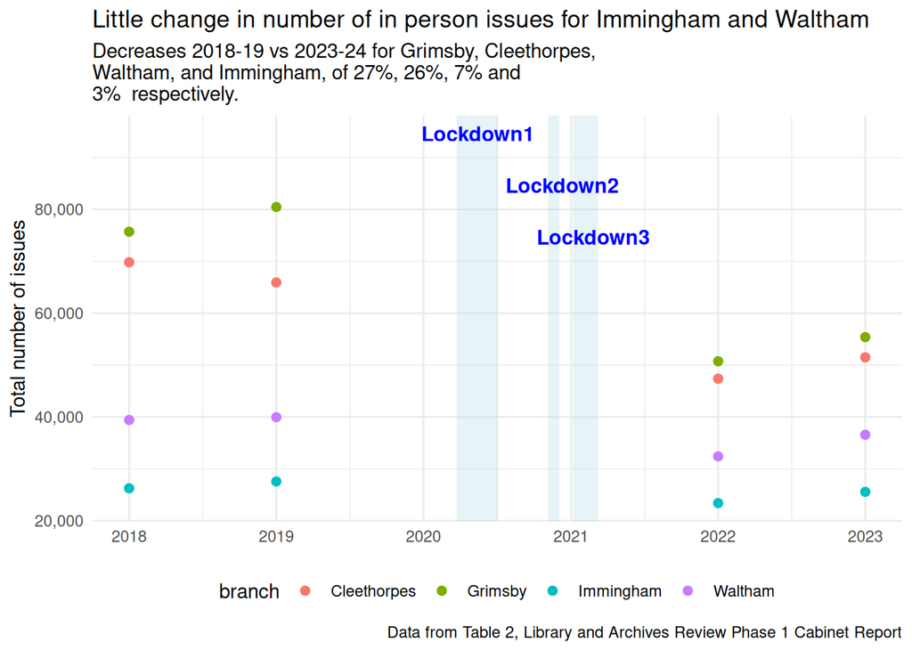

The plot of Total number of physical issues by branch clearly shows **little change in the number of physical issues pre and post-Covid for both Immingham and Waltham** and that the decline in physical issues for Grimsby and Cleethorpes is much less than the headline decline in physical visits. Here, I draw attention to Table 1 - Emerging themes from consultation and engagement for library service and archives future service design, section 1.18. In particular Section (5) User experience. Here it states that **Book stock and wider materials are valued and important for service users, recognizing that the library service is more than just books, however reading provision should remain a core focus.** With this in mind, **why was physical visits chosen as one the headline findings in section 1.21 and not physical issues**, particularly in light of the fact that there are other factors associated with the counting of physical visits that are not related to reading provision?

[figure not shown]

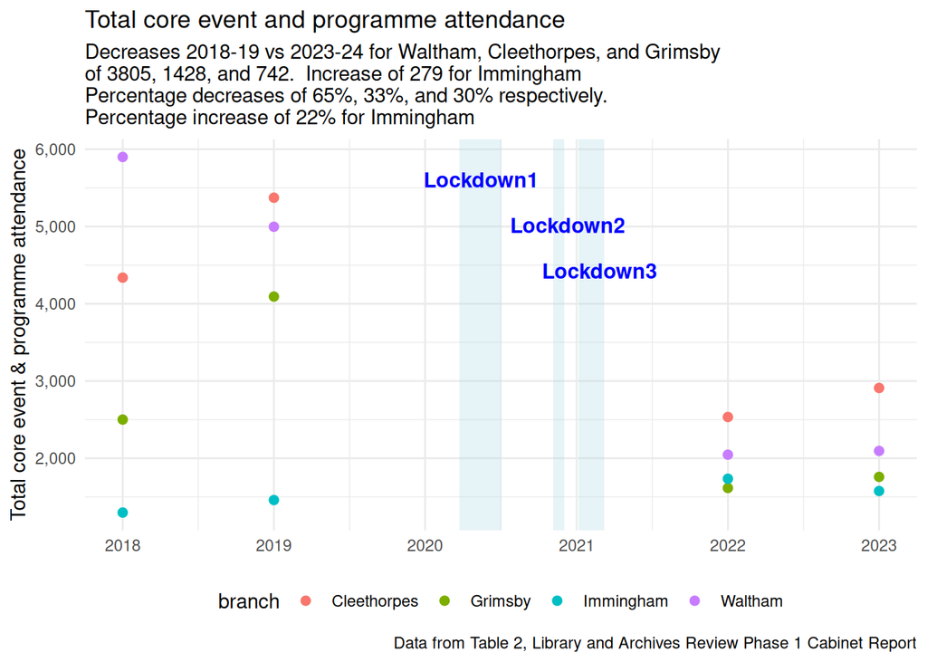

It is not explained exactly what a core event & programme attendance is, nor how it is measured. The plot of Total core event and programme attendance clearly shows decreases on comparison of the period 2018-19 with 2023-24 at three branches and an increase at the other, and that there is a large period in which data is missing for which service would have been available a large proportion of that period. The assessment report states “*however, attendance at events and activities has remained constant, supported by grant funded programmes providing new activities.*” But notice the **large variance in the measure.** For example, for Grimsby the count for the period 2019-20 was more than one and a half times that for the period 2018-19, and then the count for the period 2022-23 was two fifths of that for 2019-20. For Cleethorpes the count for the period 2022-23 was only four fifths of that for the period 2023-24. **This variance undermines and broad claims of “consistency”.**

**Do different branches define events differently (e.g. large workshop vs. casual drop in sessions)?**

### Summary and Conclusion

The findings of the needs assessment set out in appendix 1 contain multiple errors. A large amount of data is missing. A large amount of data is simply not included. The presentation of the data could be misleading. There is no description of how the measurements have been made or any evidence of an appreciation of the importance of being well informed about the nature of the measurements. There is no evidence of any appreciation of the impact of differences in building layout and service provision in the building spaces at each branch on the physical visit measure. There is no justification on the selection of particular measurements over others as those to be highlighted and presented in section 1.21. One of the measurements chosen to be highlighted is in error and overstated. The plots provided in figure 4 fail to reveal important information.

**Different measurement methods** (e.g. entry sensor vs. lending data) **can skew reported trends.**

I challenge the use of **physical visits as a headline measure**. **Library engagement should prioritise borrowing behaviour** because reading provision should remain a key focus.

The findings of the needs assessment set out in appendix 1 are deficient. **Therefore, I would not recommend and encourage the Cabinet to support them. Given these inconsistencies, I strongly recommend the Cabinet request access to full historical data, clarify how visitor metrics are measured, and ensure key service factors (e.g. access to newspapers) are properly accounted for in future reviews.**

### Phase 1 Consultation Summary

I have not fully reviewed this section. What follows are merely my immediate observations and some questions.

I think there is a **danger that readers of the report may associate “consultation” with “survey”**. In fact, on the second page in this section under the heading Headline Data it states 888 responses were received via the survey (631 completed responses). Also page 3 is headed “Survey Demographic Data”, and the Heat maps begin with the term Survey. Both consultations and surveys gather information from individuals. However, care should be taken to ensure that readers are clear that **consultations and surveys differ significantly in purpose scope and methodology.**

The total count from the table on wards is 736 and the total from the table on age is 741. Why the difference? The third table is headed “Non-Library users” relating to age data has a total count of 98. Does this mean that all 736 (or 741) respondents were library users? 736 + 98 = 834 (or 741 + 98 = 839). Neither combined total equals 888. Why is this?

This section of the report make liberal use of pie charts as a method of displaying data. It is proven (see Cleeveland and McGill or Heer and Bostock) that angle based comparisons (like those in pie charts) are far less precise than position based comparisons (like bar heights). This is because our brains are much better at estimating linear differences than subtle variations in angles. In addition they take up more space and use more ink than alternatives. In short **pie charts are a poor choice for the presentation of data and there are better alternatives.** I recommend that the pie charts are replaced with alternatives like bar charts. On top of this see the third page into this section with the heading “Survey Demographic Data”. It three tables of data and one pie chart. The pie chart is squeezed into the bottom center of the page with slice labels that are so small they are difficult to read. Why not present that data also as a table and therefore be consistent at least with the other data presented on that page?